# Help Zomato Predict Rating from the Review

### Objective: Using NLP and machine learning, make a model to predict the rating in a review

### based on the content of the text review. This will help identify cases with a mismatch.

[figure not shown]

# Import Necessary Library

```python
import numpy as np
import pandas as pd
import re
```

# 1. Load the data using read_csv function from pandas package

```python
reviews = pd.read_csv("Zomato_reviews.csv")
```

```python
reviews.head()
```

|  | rating | review_text |
| --- | --- | --- |
| 0 | 1.0 | Their service is worst, pricing in menu is dif... |
| 1 | 5.0 | really appreciate their quality and timing . I... |
| 2 | 4.0 | Went there on a Friday night, the place was su... |
| 3 | 4.0 | A very decent place serving good food.\r\nOrde... |
| 4 | 5.0 | One of the BEST places for steaks in the city.... |

# Shape Of The Data

```python
reviews.shape
```

```
(27762, 2)
```

# Information Of The Dataset

```python
reviews.info()
```

```
<class 'pandas.core.frame.DataFrame'>
RangeIndex: 27762 entries, 0 to 27761
Data columns (total 2 columns):
 #   Column       Non-Null Count  Dtype
---  ------       --------------  -----
 0   rating       27762 non-null  float64
 1   review_text  27748 non-null  object
dtypes: float64(1), object(1)
memory usage: 433.9+ KB
```

# Describe For Object

```python
reviews.select_dtypes('object').describe().T
```

|  | count | unique | top | freq |
| --- | --- | --- | --- | --- |
| review_text | 27748 | 10548 | good | 278 |

# Describe For All

```python
reviews.describe(include="all")
```

|  | rating | review_text |
| --- | --- | --- |
| count | 27762.000000 | 27748 |
| unique | NaN | 10548 |
| top | NaN | good |
| freq | NaN | 278 |
| mean | 3.665784 | NaN |
| std | 1.284573 | NaN |
| min | 1.000000 | NaN |
| 25% | 3.000000 | NaN |
| 50% | 4.000000 | NaN |
| 75% | 5.000000 | NaN |
| max | 5.000000 | NaN |

# Check Missing Values

### 2. Null values in the review text?

```python
reviews.isnull().sum()
```

```
rating          0
review_text    14
dtype: int64
```

```python
def miss_val(reviews):
    misval = reviews.isnull().sum()
    miss_per = 100 * misval/len(reviews)
    df1 = pd.concat([misval,miss_per],axis=1)
    renamed = df1.rename(columns={0:'missing_val',1:'missing %'})
    new = renamed[renamed.iloc[:,1] !=0].sort_values('missing_val',ascending=False)
    return new
```

```python
miss_val(reviews)
```

|  | missing_val | missing % |
| --- | --- | --- |
| review_text | 14 | 0.050429 |

```python
import missingno as ms
```

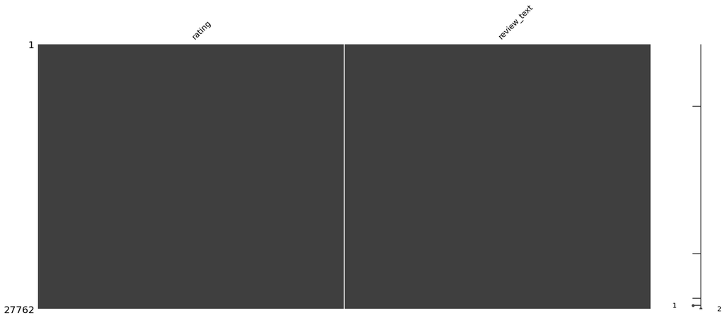

```python
ms.matrix(reviews)
```

# 14 rows are missing the review text - need to get rid of these records

### Missing Value Treatment

```python
reviews1 = reviews[~reviews.review_text.isnull()].copy()
reviews1.reset_index(inplace=True, drop=True)
```

```python
reviews1.head()
```

|  | rating | review_text |
| --- | --- | --- |
| 0 | 1.0 | Their service is worst, pricing in menu is dif... |
| 1 | 5.0 | really appreciate their quality and timing . I... |
| 2 | 4.0 | Went there on a Friday night, the place was su... |
| 3 | 4.0 | A very decent place serving good food.\r\nOrde... |
| 4 | 5.0 | One of the BEST places for steaks in the city.... |

```python
print(reviews.shape, reviews1.shape)
```

```
(27762, 2) (27748, 2)
```

# Converting to list for easy manipulation

```python
 reviews_list = reviews1.review_text.values
```

```python
len(reviews_list)
```

```
27748
```

# 3. Perform cleanup on the data

a. Normalize the casing

b. Remove extra line breaks from the text

c. Remove stop words

i. Note: Terms like ‘no’, ‘not’, ‘don’, ‘won’ are important, don’t remove

d. Remove punctuation

```python
reviews_lower = [txt.lower() for txt in reviews_list]
```

```python
reviews_lower[0:4]
```

```
['their service is worst, pricing in menu is different from bill. they can give you a bill with increased pricing. even for serving water,menu, order you need to call them 3-4 times even on a non busy day.',
 "really appreciate their quality and timing . i have tried the thattil kutti dosa i've been addicted to the dosa really and the chutney... really good and money worth much better than a thattukada must try it",
 'went there on a friday night, the place was surprisingly empty. interesting menu which is almost fully made of dosas. i had bullseye dosa and cheese masala dosa. the bullseye dosa was really good, with the egg perfectly cooked to a half boiled state. the masala in the cheese masala was good, but t…
 'a very decent place serving good food.\r\nordered chilli fish, chicken & pork sizzler.\r\neverything tasted good but pork could have been slightly better cooked.\r\ntried 2 beverages, both were very sweet.']
```

# Remove extra line breaks

```python
reviews_lower = [" ".join(txt.split()) for txt in reviews_lower]
```

```python
reviews_lower[0:4]
```

```
['their service is worst, pricing in menu is different from bill. they can give you a bill with increased pricing. even for serving water,menu, order you need to call them 3-4 times even on a non busy day.',
 "really appreciate their quality and timing . i have tried the thattil kutti dosa i've been addicted to the dosa really and the chutney... really good and money worth much better than a thattukada must try it",
 'went there on a friday night, the place was surprisingly empty. interesting menu which is almost fully made of dosas. i had bullseye dosa and cheese masala dosa. the bullseye dosa was really good, with the egg perfectly cooked to a half boiled state. the masala in the cheese masala was good, but t…
 'a very decent place serving good food. ordered chilli fish, chicken & pork sizzler. everything tasted good but pork could have been slightly better cooked. tried 2 beverages, both were very sweet.']
```

# Tokenize

### Tokenization is breaking the raw text into small chunks

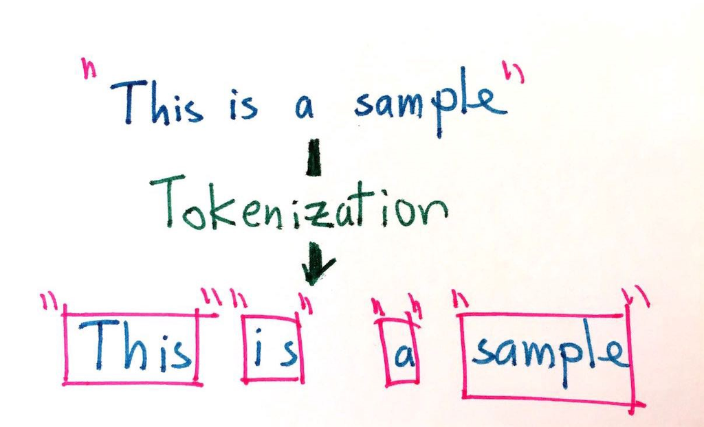

```python
from nltk.tokenize import word_tokenize
```

```python
print(word_tokenize(reviews_lower[0]))
```

```
['their', 'service', 'is', 'worst', ',', 'pricing', 'in', 'menu', 'is', 'different', 'from', 'bill', '.', 'they', 'can', 'give', 'you', 'a', 'bill', 'with', 'increased', 'pricing', '.', 'even', 'for', 'serving', 'water', ',', 'menu', ',', 'order', 'you', 'need', 'to', 'call', 'them', '3-4', 'times',…
```